[BACK](https://www.slopezza.com/playground)  
[GitHub repository](https://github.com/smlopezza/BankTransactions)  
[Kaggle](https://www.kaggle.com/smlopezza/topic-modelling-of-banking-transactions-using-lda)

# Topic Modelling of Banking Transactions using Latent Dirichlet Allocation (LDA)

## Objective of the project

This is a personal project to get insights related to my personal expenses. In this notebook I analyze bank statements from my everyday banking account and my two credit cards using Topic Modelling with the idea to classify transactions. I also take a look on how my transactions have been affected by COVID 19.

In this notebook I am practicing my skills in:

- **Pandas** for working with files and datasets
- **Seaborn** and **Ploty** to plot the different figures
- **Scikit-Learn** - I use Latent Dirichlet Allocation (**LDA**) for analysis of the transactions description field

### Considerations

- Data is available from Nov 2018. I will use data between Dec. 1st, 2018 and Sep. 30, 2020
- Transactions are made in Canadian dollars (CAD)
- If you would like to do a similar analysis, your personal bank has the option to export your transactions to a CSV file.

### Funfact

I spent 172.89 CAD in coffee since Dec. 1, 2018. I love coffee!

### Graphical summary of results

- The transactions from the 3 financial products were classified in 10 topics.

[figure not shown]

## Contents

1. Pre-processing
2. Exploratory Data Analysis (EDA)
3. Topic Modelling
4. Visualization
5. Conclusions

## Initial setup

- Import the needed packages: pandas, numpy and seaborn, matplotlib and plotly

```python
import numpy as np
import pandas as pd
import seaborn as sns
import matplotlib.pyplot as plt

from plotly.subplots import make_subplots
import plotly.graph_objects as go
import plotly.offline as px

import datetime
import re   # Regular expressions

import nltk   # natural language tool kit
from sklearn.model_selection import GridSearchCV
from sklearn.feature_extraction.text import CountVectorizer
from sklearn.decomposition import LatentDirichletAllocation

import warnings
warnings.filterwarnings('ignore')

%matplotlib inline
print("Pandas version: ", pd.__version__)

# To export plotly figures in an HTML version of the jupyter notebook
px.init_notebook_mode()
```

```
Pandas version:  1.1.2
```

## Pre-processing

- For the pre-processing of the data, the CSV files generated by the two different banks are read. Then, null values corresponding to "Transaction Type" are filled with value from "Transaction description". Finally, some features are added: year, month, day, week of year, weekday.

### Read Dataset

```python
# Read the dataset for Banking account
df_banking = pd.read_csv('banking.csv', header=None, usecols=[0, 1, 3, 4], names = ['Transaction Date', 'Quantity', 'Transaction description', 'Transaction Type'], parse_dates=['Transaction Date'])
df_banking = df_banking.set_index('Transaction Date')
print(f'Shape of dataframe: {df_banking.shape}')
df_banking = df_banking.sort_index()
df_banking.head()
```

```
Shape of dataframe: (704, 3)
```

| Transaction Date | Quantity | Transaction description | Transaction Type |
| --- | --- | --- | --- |
| 2018-11-01 | -550.00 | WITHDRAWAL | MB-EMAIL MONEY TRF |
| 2018-11-01 | 45.00 | Miscellaneous Payment | PAYPAL |
| 2018-11-01 | -0.00 | Service Charge | MB-FREE EMAIL MONEY TRF |
| 2018-11-01 | -50.00 | Customer Transfer Dr. | MB-TRANSFER |
| 2018-11-01 | -37.91 | Customer Transfer Dr. | MB-TRANSFER |

```python
# Read the dataset for credit card bank 1
df_creditcard_bank01 = pd.read_csv('bank01_creditcard.csv', header=None, names = ['Transaction Date', 'Transaction description', 'Quantity'],  parse_dates=['Transaction Date'])
df_creditcard_bank01 = df_creditcard_bank01.set_index('Transaction Date')
print(f'Shape of dataframe: {df_creditcard_bank01.shape}')
df_creditcard_bank01 = df_creditcard_bank01.sort_index()
df_creditcard_bank01.head()
```

```
Shape of dataframe: (559, 2)
```

| Transaction Date | Transaction description | Quantity |
| --- | --- | --- |
| 2018-11-02 | ADOBE *PHOTOGPHY PLAN 8008336687 CA AMT ... | -15.18 |
| 2018-11-02 | MB-CREDIT CARD/LOC PAY. FROM - 55376... | 15.24 |
| 2018-11-03 | MB-CREDIT CARD/LOC PAY. FROM - 55376... | 57.80 |
| 2018-11-03 | KOODO MOBILE PAC EDMONTON AB | -57.80 |
| 2018-11-04 | AMZN Mktp CA*M84F08MK2 WWW.AMAZON.CAON | -38.98 |

```python
# Read the dataset for credit card bank 2 and join them (In this case the transactions available are only last 25 months and you can download 12 months at a time)
df_creditcard_bank02a = pd.read_csv('bank02_creditcard_01.csv', usecols=[0, 3, 4, 5, 6], parse_dates=['Transaction Date'])
df_creditcard_bank02b = pd.read_csv('bank02_creditcard_02.csv', usecols=[0, 3, 4, 5, 6], parse_dates=['Transaction Date'])
df_creditcard_bank02 = pd.concat([df_creditcard_bank02a, df_creditcard_bank02b ])
df_creditcard_bank02 = df_creditcard_bank02.set_index('Transaction Date')

# Debit column should be negative
df_creditcard_bank02['Debit'] = -df_creditcard_bank02['Debit']
# Null values should be zero in Debit and credit columns. A new column 'Quantity' is created from Debit and Credit
df_creditcard_bank02.loc[df_creditcard_bank02['Debit'].isnull(), 'Debit'] = 0
df_creditcard_bank02.loc[df_creditcard_bank02['Credit'].isnull(), 'Credit'] = 0
df_creditcard_bank02['Quantity'] = df_creditcard_bank02['Debit'] + df_creditcard_bank02['Credit']

print(f'Shape of dataframe: {df_creditcard_bank02.shape}')

# df_creditcard_bank02 = df_creditcard_bank02.rename(columns={'Debit': 'Quantity'})
df_creditcard_bank02 = df_creditcard_bank02.sort_index()
df_creditcard_bank02.head()
```

```
Shape of dataframe: (370, 5)
```

| Transaction Date | Description | Category | Debit | Credit | Quantity |
| --- | --- | --- | --- | --- | --- |
| 2018-10-27 | COSTCO WHOLESALE W530 | Merchandise | -317.69 | 0.00 | -317.69 |
| 2018-10-30 | PAYMENT | Payment/Credit | 0.00 | 317.69 | 317.69 |
| 2018-10-31 | PAYMENT | Payment/Credit | 0.00 | 120.00 | 120.00 |
| 2018-11-15 | INTEREST CHARGES | Fee/Interest Charge | -12.14 | 0.00 | -12.14 |
| 2018-11-23 | LACSA 1133M5A | Airfare | -1174.44 | 0.00 | -1174.44 |

### Check if there are null values

```python
df_banking.info()
```

```
<class 'pandas.core.frame.DataFrame'>
DatetimeIndex: 704 entries, 2018-11-01 to 2020-10-13
Data columns (total 3 columns):
 #   Column                   Non-Null Count  Dtype
---  ------                   --------------  -----
 0   Quantity                 704 non-null    float64
 1   Transaction description  704 non-null    object
 2   Transaction Type         678 non-null    object
dtypes: float64(1), object(2)
memory usage: 22.0+ KB
```

```python
# Fill NULL transaction type with "Transaction description"
df_banking['Transaction Type'] = df_banking['Transaction Type'].fillna(df_banking['Transaction description'])
```

```python
df_creditcard_bank01.info()
```

```
<class 'pandas.core.frame.DataFrame'>
DatetimeIndex: 559 entries, 2018-11-02 to 2020-10-14
Data columns (total 2 columns):
 #   Column                   Non-Null Count  Dtype
---  ------                   --------------  -----
 0   Transaction description  559 non-null    object
 1   Quantity                 559 non-null    float64
dtypes: float64(1), object(1)
memory usage: 13.1+ KB
```

```python
df_creditcard_bank02.info()
```

```
<class 'pandas.core.frame.DataFrame'>
DatetimeIndex: 370 entries, 2018-10-27 to 2020-09-21
Data columns (total 5 columns):
 #   Column       Non-Null Count  Dtype
---  ------       --------------  -----
 0   Description  370 non-null    object
 1   Category     370 non-null    object
 2   Debit        370 non-null    float64
 3   Credit       370 non-null    float64
 4   Quantity     370 non-null    float64
dtypes: float64(3), object(2)
memory usage: 17.3+ KB
```

### Addition of features for year, month , day

```python
df_banking['Year'] = df_banking.index.year
df_banking['Month'] = df_banking.index.month
df_banking['Day'] = df_banking.index.day
df_banking['Week'] = df_banking.index.isocalendar().week
df_banking['Weekday'] = df_banking.index.weekday

df_creditcard_bank01['Year'] = df_creditcard_bank01.index.year
df_creditcard_bank01['Month'] = df_creditcard_bank01.index.month
df_creditcard_bank01['Day'] = df_creditcard_bank01.index.day
df_creditcard_bank01['Week'] = df_creditcard_bank01.index.isocalendar().week
df_creditcard_bank01['Weekday'] = df_creditcard_bank01.index.weekday

df_creditcard_bank02['Year'] = df_creditcard_bank02.index.year
df_creditcard_bank02['Month'] = df_creditcard_bank02.index.month
df_creditcard_bank02['Day'] = df_creditcard_bank02.index.day
df_creditcard_bank02['Week'] = df_creditcard_bank02.index.isocalendar().week
df_creditcard_bank02['Weekday'] = df_creditcard_bank02.index.weekday
```

## Exploratory Data Analysis (EDA)

### Maximum and minimum transactions

```python
min_Banking = df_banking["Quantity"].min()
min_Banking_date = df_banking["Quantity"].idxmin()
max_Banking = df_banking["Quantity"].max()
max_Banking_date = df_banking["Quantity"].idxmax()

print(f"The minimum value transaction for banking account was: {min_Banking} CAD on {min_Banking_date.date()}")
print(f"The maximum value transaction for banking account was: {max_Banking} CAD on {max_Banking_date.date()}")
```

```
The minimum value transaction for banking account was: -2250.0 CAD on 2020-09-18
The maximum value transaction for banking account was: 4312.17 CAD on 2020-03-30
```

```python
min_Credit_bank01 = df_creditcard_bank01["Quantity"].min()
min_Credit_bank01_date = df_creditcard_bank01["Quantity"].idxmin()
max_Credit_bank01 = df_creditcard_bank01["Quantity"].max()
max_Credit_bank01_date = df_creditcard_bank01["Quantity"].idxmax()

print(f"The minimum value transaction for banking account was: {min_Credit_bank01} CAD on {min_Credit_bank01_date.date()}")
print(f"The maximum value transaction for banking account was: {max_Credit_bank01} CAD on {max_Credit_bank01_date.date()}")
```

```
The minimum value transaction for banking account was: -327.68 CAD on 2020-06-01
The maximum value transaction for banking account was: 500.0 CAD on 2020-10-05
```

```python
min_Credit_bank02 = df_creditcard_bank02["Quantity"].min()
min_Credit_bank02_date = df_creditcard_bank02["Quantity"].idxmin()
max_Credit_bank02 = df_creditcard_bank02["Quantity"].max()
max_Credit_bank02_date = df_creditcard_bank02["Quantity"].idxmax()

print(f"The minimum value transaction for banking account was: {min_Credit_bank02} CAD on {min_Credit_bank02_date.date()}")
print(f"The maximum value transaction for banking account was: {max_Credit_bank02} CAD on {max_Credit_bank02_date.date()}")
```

```
The minimum value transaction for banking account was: -2189.1 CAD on 2019-11-29
The maximum value transaction for banking account was: 1220.0 CAD on 2020-03-04
```

### Minimum date available

```python
print(f"First available date of banking data is {df_banking.index[0].date()}")
print(f"First available date of credit card bank 1 data is {df_creditcard_bank01.index[0].date()}")
print(f"First available date of credit card bank 2 data is {df_creditcard_bank02.index[0].date()}")
```

```
First available date of banking data is 2018-11-01
First available date of credit card bank 1 data is 2018-11-02
First available date of credit card bank 2 data is 2018-10-27
```

### Distribution plots

```python
fig = make_subplots(rows=1, cols=3, subplot_titles=("Banking", "Credit Card 1", "Credit Card 2"))

fig.add_trace(
    go.Histogram(x=df_banking["Quantity"].values, name="Banking"),
    row=1, col=1
)

fig.add_trace(
    go.Histogram(x=df_creditcard_bank01["Quantity"].values, name="Credit Card 1"),
    row=1, col=2
)

fig.add_trace(
    go.Histogram(x=df_creditcard_bank02["Quantity"].values, name="Credit Card 2"),
    row=1, col=3
)

fig.update_layout(height=400, width=800, title_text="Histograms for different financial products")
fig.update_xaxes(title_text="Quantity", row=1, col=1)
fig.update_xaxes(title_text="Quantity", row=1, col=2)
fig.update_xaxes(title_text="Quantity", row=1, col=3)
fig.update_yaxes(title_text="Count", row=1, col=1)

fig.update_traces(marker_line_width=1.5, opacity=0.6)

fig.show()
```

[interactive chart not shown]

### Transactions in time

```
[Text(0.5, 0, 'Date'),
```

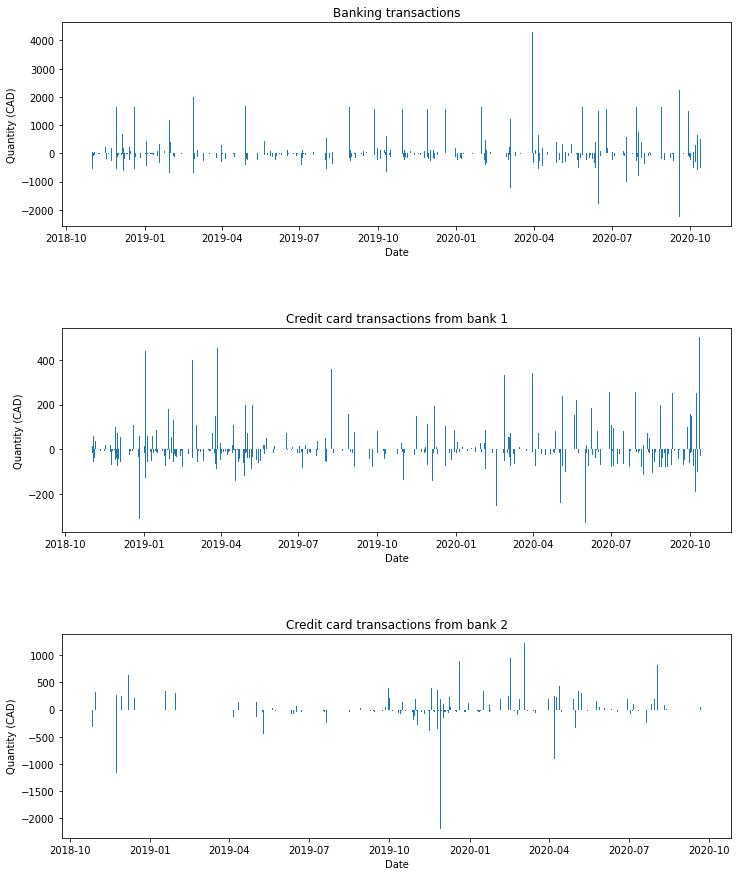

```python
# Create figure and plot space
fig, axes = plt.subplots(3, 1, figsize=(12, 15))
fig.subplots_adjust(hspace=0.5)

# For banking
axes[0].bar(df_banking.index.values, df_banking['Quantity'])
axes[1].bar(df_creditcard_bank01.index.values, df_creditcard_bank01['Quantity'])
axes[2].bar(df_creditcard_bank02.index.values, df_creditcard_bank02['Quantity'])

# Set title and labels for axes
axes[0].set(xlabel="Date", ylabel="Quantity (CAD)", title="Banking transactions")
axes[1].set(xlabel="Date", ylabel="Quantity (CAD)", title="Credit card transactions from bank 1")
axes[2].set(xlabel="Date", ylabel="Quantity (CAD)", title="Credit card transactions from bank 2")
```

### Transactions by week and weekday

I am interested to see if the month, the day of the week, the day of month or the week of the year will make a difference

```python
fig = make_subplots(rows=3, cols=1, subplot_titles=("Banking", "Credit Card 1", "Credit Card 2"))

fig.add_trace(
    go.Histogram(x=df_banking["Month"].values, name="Banking"),
    row=1, col=1
)

fig.add_trace(
    go.Histogram(x=df_creditcard_bank01["Month"].values, name="Credit Card 1"),
    row=2, col=1
)

fig.add_trace(
    go.Histogram(x=df_creditcard_bank02["Month"].values, name="Credit Card 2"),
    row=3, col=1
)

fig.update_layout(height=800, width=800, title_text="Plot for different financial products in time")
fig.update_xaxes(title_text="Month", row=3, col=1)
fig.update_yaxes(title_text="Count", row=1, col=1)
fig.update_yaxes(title_text="Count", row=2, col=1)
fig.update_yaxes(title_text="Count", row=3, col=1)

fig.update_traces(marker_line_width=1.5, opacity=0.6)

fig.show()
```

[interactive chart not shown]

```python
fig = make_subplots(rows=3, cols=1, subplot_titles=("Banking", "Credit Card 1", "Credit Card 2"))

fig.add_trace(
    go.Histogram(x=df_banking["Day"].values, name="Banking"),
    row=1, col=1
)

fig.add_trace(
    go.Histogram(x=df_creditcard_bank01["Day"].values, name="Credit Card 1"),
    row=2, col=1
)

fig.add_trace(
    go.Histogram(x=df_creditcard_bank02["Day"].values, name="Credit Card 2"),
    row=3, col=1
)

fig.update_layout(height=800, width=800, title_text="Plot for different financial products in time")
fig.update_xaxes(title_text="Day", row=3, col=1)
fig.update_yaxes(title_text="Count", row=1, col=1)
fig.update_yaxes(title_text="Count", row=2, col=1)
fig.update_yaxes(title_text="Count", row=3, col=1)

fig.update_traces(marker_line_width=1.5, opacity=0.6)
fig.show()
```

[interactive chart not shown]

```python
fig = make_subplots(rows=3, cols=1, subplot_titles=("Banking", "Credit Card 1", "Credit Card 2"))

fig.add_trace(
    go.Histogram(x=df_banking["Week"].values, name="Banking"),
    row=1, col=1
)

fig.add_trace(
    go.Histogram(x=df_creditcard_bank01["Week"].values, name="Credit Card 1"),
    row=2, col=1
)

fig.add_trace(
    go.Histogram(x=df_creditcard_bank02["Week"].values, name="Credit Card 2"),
    row=3, col=1
)

fig.update_layout(height=800, width=800, title_text="Plot for different financial products in time")
fig.update_xaxes(title_text="Week", row=3, col=1)
fig.update_yaxes(title_text="Count", row=1, col=1)
fig.update_yaxes(title_text="Count", row=2, col=1)
fig.update_yaxes(title_text="Count", row=3, col=1)

fig.update_traces(marker_line_width=1.5, opacity=0.6)
fig.show()
```

[interactive chart not shown]

```python
fig = make_subplots(rows=3, cols=1, subplot_titles=("Banking", "Credit Card 1", "Credit Card 2"))

fig.add_trace(
    go.Histogram(x=df_banking["Weekday"].values, name="Banking"),
    row=1, col=1
)

fig.add_trace(
    go.Histogram(x=df_creditcard_bank01["Weekday"].values, name="Credit Card 1"),
    row=2, col=1
)

fig.add_trace(
    go.Histogram(x=df_creditcard_bank02["Weekday"].values, name="Credit Card 2"),
    row=3, col=1
)

fig.update_layout(height=800, width=800, title_text="Plot for different financial products in time")
fig.update_xaxes(title_text="Weekday", row=3, col=1)
fig.update_yaxes(title_text="Count", row=1, col=1)
fig.update_yaxes(title_text="Count", row=2, col=1)
fig.update_yaxes(title_text="Count", row=3, col=1)

fig.update_traces(marker_line_width=1.5, opacity=0.6)
fig.show()
```

[interactive chart not shown]

### Comparision 2019 vs 2020

```python
df_banking.head()
```

| Transaction Date | Quantity | Transaction description | Transaction Type | Year | Month | Day | Week | Weekday |
| --- | --- | --- | --- | --- | --- | --- | --- | --- |
| 2018-11-01 | -550.00 | WITHDRAWAL | MB-EMAIL MONEY TRF | 2018 | 11 | 1 | 44 | 3 |
| 2018-11-01 | 45.00 | Miscellaneous Payment | PAYPAL | 2018 | 11 | 1 | 44 | 3 |
| 2018-11-01 | -0.00 | Service Charge | MB-FREE EMAIL MONEY TRF | 2018 | 11 | 1 | 44 | 3 |
| 2018-11-01 | -50.00 | Customer Transfer Dr. | MB-TRANSFER | 2018 | 11 | 1 | 44 | 3 |
| 2018-11-01 | -37.91 | Customer Transfer Dr. | MB-TRANSFER | 2018 | 11 | 1 | 44 | 3 |

```python
# Transactions in 2019
df_2019_credit02_IN = df_creditcard_bank01[ (df_creditcard_bank01['Year'] == 2019) & (df_creditcard_bank01['Quantity'] > 0 )]
df_2019_credit02_OUT = df_creditcard_bank01[ (df_creditcard_bank01['Year'] == 2019) & (df_creditcard_bank01['Quantity'] < 0 )]

df_2019_credit02_IN
```

| Transaction Date | Transaction description | Quantity | Year | Month | Day | Week | Weekday |
| --- | --- | --- | --- | --- | --- | --- | --- |
| 2019-01-02 | MB-CREDIT CARD/LOC PAY. FROM - 55376... | 15.82 | 2019 | 1 | 2 | 1 | 2 |
| 2019-01-03 | MB-CREDIT CARD/LOC PAY. FROM - 55376... | 438.75 | 2019 | 1 | 3 | 1 | 3 |
| 2019-01-03 | MB-CREDIT CARD/LOC PAY. FROM - 55376... | 35.00 | 2019 | 1 | 3 | 1 | 3 |
| 2019-01-05 | MB-CREDIT CARD/LOC PAY. FROM - 55376... | 57.80 | 2019 | 1 | 5 | 1 | 5 |
| 2019-01-11 | MB-CREDIT CARD/LOC PAY. FROM - 55376... | 60.12 | 2019 | 1 | 11 | 2 | 4 |
| ... | ... | ... | ... | ... | ... | ... | ... |
| 2019-11-29 | MB-CREDIT CARD/LOC PAY. FROM - 55376... | 20.58 | 2019 | 11 | 29 | 48 | 4 |
| 2019-12-07 | MB-CREDIT CARD/LOC PAY. FROM - 55376... | 193.39 | 2019 | 12 | 7 | 49 | 5 |
| 2019-12-10 | MB-CREDIT CARD/LOC PAY. FROM - 55376... | 12.46 | 2019 | 12 | 10 | 50 | 1 |
| 2019-12-20 | MB-CREDIT CARD/LOC PAY. FROM - 55376... | 105.02 | 2019 | 12 | 20 | 51 | 4 |
| 2019-12-31 | MB-CREDIT CARD/LOC PAY. FROM - 55376... | 85.00 | 2019 | 12 | 31 | 1 | 1 |

68 rows × 7 columns

```python
data = [
    [2019, df_banking[ (df_banking['Year'] == 2019) & (df_banking['Quantity'] > 0 )]['Quantity'].sum(),  -df_banking[ (df_banking['Year'] == 2019) & (df_banking['Quantity'] < 0 )]['Quantity'].sum(), 'Banking'],
    [2019, df_creditcard_bank01[ (df_creditcard_bank01['Year'] == 2019) & (df_creditcard_bank01['Quantity'] > 0 )]['Quantity'].sum(),  -df_creditcard_bank01[ (df_creditcard_bank01['Year'] == 2019) & (df_creditcard_bank01['Quantity'] < 0 )]['Quantity'].sum(), 'Credit Card Bank 1'],
    [2019, df_creditcard_bank02[ (df_creditcard_bank02['Year'] == 2019) & (df_creditcard_bank02['Quantity'] > 0 )]['Quantity'].sum(),  -df_creditcard_bank02[ (df_creditcard_bank02['Year'] == 2019) & (df_creditcard_bank02['Quantity'] < 0 )]['Quantity'].sum(), 'Credit Card Bank 2'],
    [2020, df_banking[ (df_banking['Year'] == 2020) & (df_banking['Quantity'] > 0 )]['Quantity'].sum(),  -df_banking[ (df_banking['Year'] == 2020) & (df_banking['Quantity'] < 0 )]['Quantity'].sum(), 'Banking'],
    [2020, df_creditcard_bank01[ (df_creditcard_bank01['Year'] == 2020) & (df_creditcard_bank01['Quantity'] > 0 )]['Quantity'].sum(),  -df_creditcard_bank01[ (df_creditcard_bank01['Year'] == 2020) & (df_creditcard_bank01['Quantity'] < 0 )]['Quantity'].sum(), 'Credit Card Bank 1'],
    [2020, df_creditcard_bank02[ (df_creditcard_bank02['Year'] == 2020) & (df_creditcard_bank02['Quantity'] > 0 )]['Quantity'].sum(),  -df_creditcard_bank02[ (df_creditcard_bank02['Year'] == 2020) & (df_creditcard_bank02['Quantity'] < 0 )]['Quantity'].sum(), 'Credit Card Bank 2']
 ]

df_transactionsSummary = pd.DataFrame(data = data, columns=['Year', 'IN', 'OUT', 'Origin'])
df_transactionsSummary['Difference'] = df_transactionsSummary['IN'] - df_transactionsSummary['OUT']
df_transactionsSummary
```

|  | Year | IN | OUT | Origin | Difference |
| --- | --- | --- | --- | --- | --- |
| 0 | 2019 | 28018.69 | 27639.28 | Banking | 379.41 |
| 1 | 2019 | 6094.79 | 5796.53 | Credit Card Bank 1 | 298.26 |
| 2 | 2019 | 6954.62 | 9950.12 | Credit Card Bank 2 | -2995.50 |
| 3 | 2020 | 39224.44 | 39765.53 | Banking | -541.09 |
| 4 | 2020 | 6579.79 | 6556.54 | Credit Card Bank 1 | 23.25 |
| 5 | 2020 | 8784.65 | 5146.45 | Credit Card Bank 2 | 3638.20 |

```python
change_bank = df_transactionsSummary[df_transactionsSummary['Origin'] == "Banking"]['IN'].reset_index(drop=True).values
change_CC1 = df_transactionsSummary[df_transactionsSummary['Origin'] == "Credit Card Bank 1"]['OUT'].reset_index(drop=True).values
change_CC2 = df_transactionsSummary[df_transactionsSummary['Origin'] == "Credit Card Bank 2"]['OUT'].reset_index(drop=True).values

print('Debt (IN):', "{:.2f}".format(100*(change_bank[1] - change_bank[0])/change_bank[0]) + '%' )
print('Credit Card 1 (OUT):', "{:.2f}".format(100*(change_CC1[1] - change_CC1[0])/change_CC1[0]) + '%')
print('Credit Card 2 (OUT):', "{:.2f}".format(100*(change_CC2[1] - change_CC2[0])/change_CC2[0]) + '%')
```

```
Debt (IN): 39.99%
Credit Card 1 (OUT): 13.11%
Credit Card 2 (OUT): -48.28%
```

```python
df_transactionsSummary_banking = df_transactionsSummary[df_transactionsSummary['Origin'] == 'Banking']
import plotly.express as px
fig = px.bar(df_transactionsSummary_banking, x="Year", y=["IN", "OUT"],
             labels={
                     "value": "Quantity (CAD)",
                     "variable": "Type"
                 },
              barmode='group',
             height=400, width=600)

fig.update_traces(marker_line_width=1.5, opacity=0.6)
fig.update_layout(title_text='Quantity of Debit Transactions - 2019 vs 2020')

fig.show()
```

[interactive chart not shown]

```python
df_transactionsSummary_CC1 = df_transactionsSummary[df_transactionsSummary['Origin'] == 'Credit Card Bank 1']
import plotly.express as px
fig = px.bar(df_transactionsSummary_CC1, x="Year", y=["IN", "OUT"],
              labels={
                     "value": "Quantity (CAD)",
                     "variable": "Type"
                 },
              barmode='group',
             height=400, width=600)

fig.update_traces(marker_line_width=1.5, opacity=0.6)
fig.update_layout(title_text='Quantity of Credit Card Transactions (Bank 1) - 2019 vs 2020')

fig.show()
```

[interactive chart not shown]

```python
df_transactionsSummary_CC2 = df_transactionsSummary[df_transactionsSummary['Origin'] == 'Credit Card Bank 2']

fig = px.bar(df_transactionsSummary_CC2, x="Year", y=["IN", "OUT"],
              labels={
                     "value": "Quantity (CAD)",
                     "variable": "Type"
                 },
              barmode='group',
             height=400, width=600)

fig.update_traces(marker_line_width=1.5, opacity=0.6)
fig.update_layout(title_text='Quantity of Credit Card Transactions (Bank 2) - 2019 vs 2020')

fig.show()
```

[interactive chart not shown]

### Some conclusion from EDA

- The months where I made more transactions were January and December. A peak in June/July can also be observed. This is consistent with Summer and Christmas seasons

- Quantity of IN debit transactions in 2020 had increased in 39.99%
- Quantity of Output credit card transactions from bank 1 (limit 1000 CAD) had increased in 13.11%
- Quantity of Output credit card transactions from bank 2 (limit 5000 CAD) had decreased in 48.28%

## Topic Modelling

The idea of Topic Modelling in Natural Language Processing is to discover abstract topics in documents. The Latent Dirichlet Allocation [(LDA)](https://en.wikipedia.org/wiki/Latent_Dirichlet_allocation) is a generative statistical model that allows sets of observations to be explained by unobserved groups. This is within the *Unsupervised Learning* category. Some examples can be found here: [Example 1](https://blog.usejournal.com/nlp-for-topic-modeling-summarization-of-financial-documents-10-k-q-93070db96c1d), [Example 2](https://medium.com/@yanlinc/how-to-build-a-lda-topic-model-using-from-text-601cdcbfd3a6), [Example 3](https://towardsdatascience.com/end-to-end-topic-modeling-in-python-latent-dirichlet-allocation-lda-35ce4ed6b3e0)

Some preparation is needed first.

### Pre preposing

#### Selection of dates of interest

- Data is available from different dates according to the financial product. The selected dates are from Dec 1, 2018 to Sep 30, 2020

```python
date01 = datetime.date(2018, 12, 1)
date02 = datetime.date(2020, 9, 30)
df_banking = df_banking[(df_banking.index.date >= date01) & (df_banking.index.date <= date02)]
df_creditcard_bank01 = df_creditcard_bank01[(df_creditcard_bank01.index.date >= date01) & (df_creditcard_bank01.index.date <= date02)]
df_creditcard_bank02 = df_creditcard_bank02[(df_creditcard_bank02.index.date >= date01) & (df_creditcard_bank02.index.date <= date02)]
```

#### Quick view on description fields

A quick look on the description field show us that we can use it to help the classification of transactions. It is interesting that Bank 2 provides a category field. For this study that column won't be used.

```python
df_banking['Transaction description'].unique()[:5]
```

```
array(['Bill Payment           ', 'POS Purchase           ',
       'DEPOSIT                ', 'ABM Withdrawal',
       'Miscellaneous Payment  '], dtype=object)
```

```python
df_banking['Transaction Type'].unique()[:5]
```

```
array(['MB-SCOTIA SCENE VISA CARD', 'FPOS TIM HORTONS #0604# QSTRAT',
       'FPOS THE BOOK STORE AT WELONDO', 'GPOS CENTRE SPOT         LONDO',
       'GPOS ENGINEERING         LONDO'], dtype=object)
```

```python
df_creditcard_bank01['Transaction description'].unique()[:5]
```

```
array(['MB-CREDIT CARD/LOC PAY.           FROM - 553760500321 ',
       'LATINO MARKET HERMIDA INCLONDON       ON  (GOOGLE PAY) ',
       'SHOPPERS DRUG MART0765   LONDON       ON  (GOOGLE PAY) ',
       'DOLLARAMA # 336          LONDON       ON  (GOOGLE PAY) ',
       'UberBV                   Amsterdam    ON '], dtype=object)
```

```python
df_creditcard_bank02['Description'].unique()[:5]
```

```
array(['PAYMENT', 'INTEREST CHARGE ADJUSTMENT', 'INTEREST CHARGES',
       'COSTCO WHOLESALE W530', 'EXITO SANTA MARTA CENT'], dtype=object)
```

```python
# Category field for second credit card wont be used
categories_CC2 = df_creditcard_bank02['Category'].unique()
print(categories_CC2.shape)
categories_CC2
```

```
(14,)
```

```
array(['Payment/Credit', 'Fee/Interest Charge', 'Merchandise', 'Dining',
       'Lodging', 'Health Care', 'Gas/Automotive', 'Other',
       'Other Services', 'Entertainment', 'Other Travel', 'Phone/Cable',
       'Professional Services', 'Airfare'], dtype=object)
```

```python
df_banking[['Transaction description', 'Transaction Type', 'Year', 'Quantity']].groupby(['Transaction description', 'Transaction Type', 'Year']).sum().head()
```

| Transaction description | Transaction Type | Year | Quantity |
| --- | --- | --- | --- |
| ABM Deposit | ABM Deposit | 2019 | 1166.80 |
| ABM Withdrawal | ABM Withdrawal | 2018 | -240.00 |
|  |  | 2019 | -686.45 |
|  |  | 2020 | -62.00 |
| Accounts Payable | UNIVERSITY OF WESTERN ONTARIO | 2019 | 961.57 |

```python
df_creditcard_bank01[['Transaction description', 'Year', 'Quantity']].groupby(['Transaction description', 'Year']).sum().head()
```

| Transaction description | Year | Quantity |
| --- | --- | --- |
| 168 SUSHI ASIAN BUFFET LONDON ON | 2019 | -79.47 |
| 64053 MACS CONV. STORES MOUNT BRYDGESON | 2020 | -120.66 |
| A&W #4614 LISTOWEL ON | 2019 | -27.75 |
| ADOBE *PHOTOGPHY PLAN 8008336687 CA AMT 11.29 UNITED STATES DOLLAR | 2018 | -15.44 |
|  | 2019 | -154.69 |

```python
df_creditcard_bank02[['Description', 'Year', 'Quantity']].groupby(['Description', 'Year']).sum().head()
```

| Description | Year | Quantity |
| --- | --- | --- |
| #293 SPORT CHEK | 2019 | -6.53 |
| 01013 MACS CONV. STORE | 2019 | -5.40 |
| 168 SUSHI ASIAN BUFFET | 2019 | -84.47 |
| 64053 MAC'S CONVENIE | 2019 | -41.89 |
| 64053 MACS CONV. STORE | 2019 | -267.74 |

#### Joining the data

I will join the three data sets. A new column corresponding to the original dataset will be created

```python
df_banking['Original DF'] = 'Banking'
df_creditcard_bank01['Original DF'] = 'Credit Card - Bank 1'
df_creditcard_bank02['Original DF'] = 'Credit Card - Bank 2'
```

```python
df_transactions_01a = df_banking.copy()
df_transactions_01a = df_transactions_01a.drop(columns=['Transaction Type'])
df_transactions_01a = df_transactions_01a.reset_index()

df_transactions_01b = df_creditcard_bank01.copy()
df_transactions_01b = df_transactions_01b.reset_index()

df_transactions_01c = df_creditcard_bank02.copy()
df_transactions_01c = df_transactions_01c.drop(columns=['Category', 'Debit', 'Credit'])
df_transactions_01c = df_transactions_01c.rename(columns={'Description': 'Transaction description'})
df_transactions_01c = df_transactions_01c.reset_index()

df_transactions_01b
```

|  | Transaction Date | Transaction description | Quantity | Year | Month | Day | Week | Weekday | Original DF |
| --- | --- | --- | --- | --- | --- | --- | --- | --- | --- |
| 0 | 2018-12-01 | MB-CREDIT CARD/LOC PAY. FROM - 55376... | 72.50 | 2018 | 12 | 1 | 48 | 5 | Credit Card - Bank 1 |
| 1 | 2018-12-01 | MB-CREDIT CARD/LOC PAY. FROM - 55376... | 68.00 | 2018 | 12 | 1 | 48 | 5 | Credit Card - Bank 1 |
| 2 | 2018-12-01 | MB-CREDIT CARD/LOC PAY. FROM - 55376... | 12.78 | 2018 | 12 | 1 | 48 | 5 | Credit Card - Bank 1 |
| 3 | 2018-12-01 | LATINO MARKET HERMIDA INCLONDON ON (GOO... | -72.50 | 2018 | 12 | 1 | 48 | 5 | Credit Card - Bank 1 |
| 4 | 2018-12-01 | SHOPPERS DRUG MART0765 LONDON ON (GOO... | -32.77 | 2018 | 12 | 1 | 48 | 5 | Credit Card - Bank 1 |
| ... | ... | ... | ... | ... | ... | ... | ... | ... | ... |
| 504 | 2020-09-27 | WINNERS 441 COLLINGWOOD ON | -42.91 | 2020 | 9 | 27 | 39 | 6 | Credit Card - Bank 1 |
| 505 | 2020-09-27 | STAPLES/BUSINESS DEPOT COLLINGWOOD ON | -37.02 | 2020 | 9 | 27 | 39 | 6 | Credit Card - Bank 1 |
| 506 | 2020-09-28 | DOLLARAMA #1222 KOMOKA ON | -30.31 | 2020 | 9 | 28 | 40 | 0 | Credit Card - Bank 1 |
| 507 | 2020-09-28 | JOLLEY`S DAIRY BAR &VIDEOFLESHERTON ON | -3.75 | 2020 | 9 | 28 | 40 | 0 | Credit Card - Bank 1 |
| 508 | 2020-09-29 | MB-CREDIT CARD/LOC PAY. FROM - 55376... | 100.00 | 2020 | 9 | 29 | 40 | 1 | Credit Card - Bank 1 |

509 rows × 9 columns

```python
frames = [df_transactions_01a, df_transactions_01b, df_transactions_01c]
df_transactions = pd.concat(frames)
df_transactions = df_transactions.reset_index().drop(columns='index').sort_values(['Transaction Date']).reset_index().drop(columns='index')
```

```python
df_transactions.head()
```

|  | Transaction Date | Quantity | Transaction description | Year | Month | Day | Week | Weekday | Original DF |
| --- | --- | --- | --- | --- | --- | --- | --- | --- | --- |
| 0 | 2018-12-01 | -68.00 | Bill Payment | 2018 | 12 | 1 | 48 | 5 | Banking |
| 1 | 2018-12-01 | 12.78 | MB-CREDIT CARD/LOC PAY. FROM - 55376... | 2018 | 12 | 1 | 48 | 5 | Credit Card - Bank 1 |
| 2 | 2018-12-01 | -72.50 | LATINO MARKET HERMIDA INCLONDON ON (GOO... | 2018 | 12 | 1 | 48 | 5 | Credit Card - Bank 1 |
| 3 | 2018-12-01 | -32.77 | SHOPPERS DRUG MART0765 LONDON ON (GOO... | 2018 | 12 | 1 | 48 | 5 | Credit Card - Bank 1 |
| 4 | 2018-12-01 | -22.94 | DOLLARAMA # 336 LONDON ON (GOO... | 2018 | 12 | 1 | 48 | 5 | Credit Card - Bank 1 |

### Text Analysis for Transaction description field

#### Pre-processing

Within the transaction description, we can see items with numbers, for example for transactions related with Dollarama have associated a number corresponding to the store. However, for this analysis what I want to know is the category of the expense and not the place. In that sense, the 'Transaction description' is converted to lower case and the numbers and symbols are eliminated.

It is important to 'clean' the transaction description field as follows:

- Making the transaction description lower case
- Erasing the special characters
- Remove stop words

```python
df_transactions[df_transactions['Transaction description'].str.contains('DOLLARAMA')].head()
```

|  | Transaction Date | Quantity | Transaction description | Year | Month | Day | Week | Weekday | Original DF |
| --- | --- | --- | --- | --- | --- | --- | --- | --- | --- |
| 4 | 2018-12-01 | -22.94 | DOLLARAMA # 336 LONDON ON (GOO... | 2018 | 12 | 1 | 48 | 5 | Credit Card - Bank 1 |
| 113 | 2019-01-17 | -15.59 | DOLLARAMA # 485 LONDON ON (GOO... | 2019 | 1 | 17 | 3 | 3 | Credit Card - Bank 1 |
| 164 | 2019-02-17 | -9.66 | DOLLARAMA # 291 STRATHROY ON | 2019 | 2 | 17 | 7 | 6 | Credit Card - Bank 1 |
| 204 | 2019-03-16 | -24.01 | DOLLARAMA #1222 KOMOKA ON | 2019 | 3 | 16 | 11 | 5 | Credit Card - Bank 1 |
| 258 | 2019-04-06 | -14.69 | DOLLARAMA #1075 LONDON ON | 2019 | 4 | 6 | 14 | 5 | Credit Card - Bank 1 |

```python
# lowercase
df_transactions['Transaction description'] = df_transactions['Transaction description'].str.lower()

# Erasing special characters
df_transactions['Transaction description'] = df_transactions['Transaction description'].str.replace('*', ' ')
df_transactions['Transaction description'] = df_transactions['Transaction description'].str.replace('.', ' ')
df_transactions['Transaction description'] = df_transactions['Transaction description'].apply(lambda x: re.sub(r'[^a-zA-Z\s\']+', ' ', x))
```

```python
df_transactions[df_transactions['Transaction description'].str.contains('dollarama')].head()
```

|  | Transaction Date | Quantity | Transaction description | Year | Month | Day | Week | Weekday | Original DF |
| --- | --- | --- | --- | --- | --- | --- | --- | --- | --- |
| 4 | 2018-12-01 | -22.94 | dollarama london on googl... | 2018 | 12 | 1 | 48 | 5 | Credit Card - Bank 1 |
| 113 | 2019-01-17 | -15.59 | dollarama london on googl... | 2019 | 1 | 17 | 3 | 3 | Credit Card - Bank 1 |
| 164 | 2019-02-17 | -9.66 | dollarama strathroy on | 2019 | 2 | 17 | 7 | 6 | Credit Card - Bank 1 |
| 204 | 2019-03-16 | -24.01 | dollarama komoka on | 2019 | 3 | 16 | 11 | 5 | Credit Card - Bank 1 |
| 258 | 2019-04-06 | -14.69 | dollarama london on | 2019 | 4 | 6 | 14 | 5 | Credit Card - Bank 1 |

```python
# Removing stop words
nltk.download('stopwords')
from nltk.corpus import stopwords
stop_words = set(stopwords.words('english'))

df_transactions['Transaction description'] = df_transactions['Transaction description'].apply(lambda x: [word for word in x.split() if word not in stop_words])
df_transactions['Transaction description'] = [' '.join(map(str, l)) for l in df_transactions['Transaction description']]

df_transactions.head()
```

|  | Transaction Date | Quantity | Transaction description | Year | Month | Day | Week | Weekday | Original DF |
| --- | --- | --- | --- | --- | --- | --- | --- | --- | --- |
| 0 | 2018-12-01 | -68.00 | bill payment | 2018 | 12 | 1 | 48 | 5 | Banking |
| 1 | 2018-12-01 | 12.78 | mb credit card loc pay | 2018 | 12 | 1 | 48 | 5 | Credit Card - Bank 1 |
| 2 | 2018-12-01 | -72.50 | latino market hermida inclondon google pay | 2018 | 12 | 1 | 48 | 5 | Credit Card - Bank 1 |
| 3 | 2018-12-01 | -32.77 | shoppers drug mart london google pay | 2018 | 12 | 1 | 48 | 5 | Credit Card - Bank 1 |
| 4 | 2018-12-01 | -22.94 | dollarama london google pay | 2018 | 12 | 1 | 48 | 5 | Credit Card - Bank 1 |

```python
df_transactions.shape
```

```
(1510, 9)
```

#### Bag of Words

First I am counting the words by splitting them to have an initial idea of the most used words. Finally, I use CountVectorizer with 1 to 3 ngrams to vectorize the 'Transaction description' field

```
- The 10 most used words are:
```

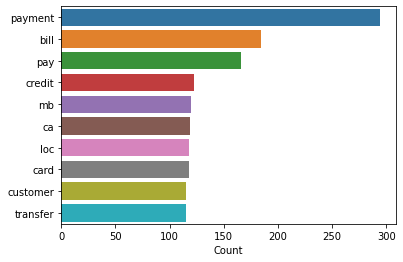

```python
# One way to count words
word_count = df_transactions['Transaction description'].str.split(expand=True).stack().value_counts()
word_count = pd.DataFrame(data=word_count, columns=['Count'])
word_count = word_count.sort_values(['Count'], ascending=False)
print('- The 10 most used words are:')

most_used = word_count[:10]

sns.barplot(x=most_used['Count'], y=most_used.index)
```

```python
# The transaction description field
documents = df_transactions['Transaction description'].values
no_features = 1500

# LDA can only use raw term counts for LDA because it is a probabilistic graphical model
tf_vectorizer = CountVectorizer(ngram_range=(1, 3), max_df=0.95, min_df=2, max_features=no_features) # Using count vectorized with 1 to 3 ngrams to count the words
tf = tf_vectorizer.fit_transform(documents)
tf_feature_names = tf_vectorizer.get_feature_names()
```

#### Latent Dirichlet allocation (LDA)

A first approach varying the number of topics to see how the perplexity and score changes was done. Then a GridSearchCV was applied to select the best conditions for the model

```python
topics = [1, 2, 3, 4, 5, 6, 7, 8, 9, 10, 11, 12, 13, 14, 15, 16, 17, 18, 19, 20]
perplexityResult = []
scoreResult = []

for no_topics in topics:
    # Run LDA
    lda = LatentDirichletAllocation(n_components=no_topics, max_iter=5, learning_method='online', learning_offset=50.,random_state=0).fit(tf)
    perplexityResult.append(lda.perplexity(tf))
    scoreResult.append(lda.score(tf))
```

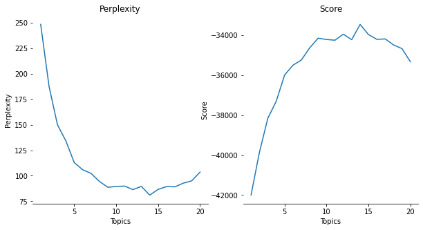

```python
fig, axes = plt.subplots(1, 2, figsize=(10, 5))
fig.subplots_adjust(hspace=0.5)

sns.despine(left=True)

sns.lineplot(topics, perplexityResult, ax=axes[0])
sns.lineplot(topics, scoreResult, ax=axes[1])

axes[0].set_title('Perplexity')
axes[0].set_xlabel('Topics')
axes[0].set_ylabel('Perplexity')

axes[1].set_title('Score')
axes[1].set_xlabel('Topics')
axes[1].set_ylabel('Score')
```

```python
# Define Search Param
search_params = {'n_components': [10, 12, 15, 20], 'learning_decay': [.5, .7, .9]}
# Init the Model
lda = LatentDirichletAllocation(max_iter=5, learning_method='online', learning_offset=50., random_state=0)
# Init Grid Search Class
model = GridSearchCV(lda, param_grid=search_params)
# Do the Grid Search
model.fit(tf)
```

```
GridSearchCV(cv=None, error_score=nan,
             estimator=LatentDirichletAllocation(batch_size=128,
                                                 doc_topic_prior=None,
                                                 evaluate_every=-1,
                                                 learning_decay=0.7,
                                                 learning_method='online',
                                                 learning_offset=50.0,
                                                 max_doc_update_iter=100,
                                                 max_iter=5,
                                                 mean_change_tol=0.001,
                                                 n_components=10, n_jobs=None,
                                                 perp_tol=0.1, random_state=0,
                                                 topic_word_prior=None,
                                                 total_samples=1000000.0,
                                                 verbose=0),
             iid='deprecated', n_jobs=None,
             param_grid={'learning_decay': [0.5, 0.7, 0.9],
                         'n_components': [10, 12, 15, 20]},
             pre_dispatch='2*n_jobs', refit=True, return_train_score=False,
             scoring=None, verbose=0)
```

```python
# Best Model
best_lda_model = model.best_estimator_
# Model Parameters
print("Best Model's Params: ", model.best_params_)
# Log Likelihood Score
print("Best Log Likelihood Score: ", model.best_score_)
# Perplexity
print("Model Perplexity: ", best_lda_model.perplexity(tf))
```

```
Best Model's Params:  {'learning_decay': 0.5, 'n_components': 10}
Best Log Likelihood Score:  -9727.33428661626
Model Perplexity:  84.10172560638006
```

## Visualization

- This auxiliary function helps to check the top words in each topic as proposed by [Aneesha Bakharia](https://medium.com/mlreview/topic-modeling-with-scikit-learn-e80d33668730#.vivglhmhv)

```python
def display_topics(model, feature_names, no_top_words):
    for topic_idx, topic in enumerate(model.components_):
        print("Topic %d:" % (topic_idx))
        print(" - ".join([feature_names[i]
                        for i in topic.argsort()[:-no_top_words - 1:-1]]))
```

```python
selectedTopics = 10
learning_decay = 0.5

lda = LatentDirichletAllocation(n_components= selectedTopics, learning_decay = learning_decay, max_iter=5, learning_method='online', learning_offset=50.,random_state=0).fit(tf)

no_top_words = 10
display_topics(lda, tf_feature_names, no_top_words)
```

```
Topic 0:
deposit - charge - service - service charge - payroll - payroll deposit - com - gst - qc - credit
Topic 1:
payment - bill - bill payment - provincial payment - provincial - accounts payable - accounts - payable - vending - sh vending
Topic 2:
ca - dollar - united states - amt united states - united - amt united - states - states dollar - united states dollar - amt
Topic 3:
amazon - ca - amazon ca - www - caon - www amazon - www amazon caon - amazon caon - amzn - amzn mktp
Topic 4:
paypal - tim - ucc - hellofresh - ucc tim - paypal hellofresh - pythonanywh - paypal pythonanywh - ucc tim upper - upper
Topic 5:
mb - pay - loc - card - credit - loc pay - mb credit card - card loc pay - mb credit - credit card
Topic 6:
customer - customer transfer - transfer - transfer cr - cr - customer transfer cr - miscellaneous - miscellaneous payment - macs - macs conv
Topic 7:
purchase - pos purchase - pos - withdrawal - abm - mar - abm withdrawal - foodland - goodfood mar - goodfood
Topic 8:
dr - customer transfer dr - transfer dr - customer transfer - transfer - customer - london - engineering - google - google pay
Topic 9:
insurance - loans - uwo - amt - colombian peso - amt colombian - amt colombian peso - colombian - peso - london
```

- To visualize better the words for each of the Topics I am using [pyLDAvis](https://pyldavis.readthedocs.io/en/latest/readme.html#:~:text=pyLDAvis%20is%20designed%20to%20help,an%20interactive%20web%2Dbased%20visualization). This is a Python library for interactive topic model visualization. The package extracts information from a fitted LDA topic model to inform an interactive web-based visualization.

```python
import pyLDAvis.sklearn
panel = pyLDAvis.sklearn.prepare(lda, tf, tf_vectorizer, mds='tsne')
pyLDAvis.display(panel)
```

[interactive chart not shown]

- Joining topics results to initial dataframe

```python
df_lda = pd.DataFrame(data=lda.transform(tf))
dominant_topic = np.argmax(df_lda.values, axis=1)
df_lda['Dominant topic'] = dominant_topic

df_result = pd.concat([df_transactions, df_lda[['Dominant topic']]], axis=1, sort=False)
df_result.head()
```

|  | Transaction Date | Quantity | Transaction description | Year | Month | Day | Week | Weekday | Original DF | Dominant topic |
| --- | --- | --- | --- | --- | --- | --- | --- | --- | --- | --- |
| 0 | 2018-12-01 | -68.00 | bill payment | 2018 | 12 | 1 | 48 | 5 | Banking | 1 |
| 1 | 2018-12-01 | 12.78 | mb credit card loc pay | 2018 | 12 | 1 | 48 | 5 | Credit Card - Bank 1 | 5 |
| 2 | 2018-12-01 | -72.50 | latino market hermida inclondon google pay | 2018 | 12 | 1 | 48 | 5 | Credit Card - Bank 1 | 3 |
| 3 | 2018-12-01 | -32.77 | shoppers drug mart london google pay | 2018 | 12 | 1 | 48 | 5 | Credit Card - Bank 1 | 8 |
| 4 | 2018-12-01 | -22.94 | dollarama london google pay | 2018 | 12 | 1 | 48 | 5 | Credit Card - Bank 1 | 8 |

- Visualization for banking transactions

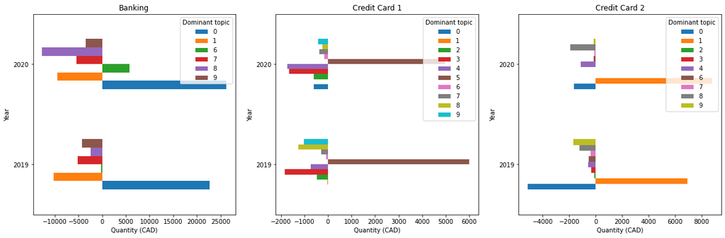

```python
fig, axes = plt.subplots(nrows=1, ncols=3, figsize=(20, 6))

dataPlot_bank = df_result.copy()
dataPlot_bank = dataPlot_bank[ (dataPlot_bank['Original DF'] == 'Banking') & (dataPlot_bank['Year'] != 2018)]
dataPlot_bank = dataPlot_bank.drop(columns=['Month', 'Week', 'Weekday', 'Day'])
dataPlot_bank = dataPlot_bank.groupby(['Year', 'Dominant topic']).sum()
dataPlot_bank['Quantity'].unstack().plot(kind='barh', stacked=False, ax=axes[0])

dataPlot_CC1 = df_result.copy()
dataPlot_CC1 = dataPlot_CC1[ (dataPlot_CC1['Original DF'] == 'Credit Card - Bank 1') & (dataPlot_CC1['Year'] != 2018)]
dataPlot_CC1 = dataPlot_CC1.drop(columns=['Month', 'Week', 'Weekday', 'Day'])
dataPlot_CC1 = dataPlot_CC1.groupby(['Year', 'Dominant topic']).sum()
dataPlot_CC1['Quantity'].unstack().plot(kind='barh', stacked=False, ax=axes[1])

dataPlot_CC2 = df_result.copy()
dataPlot_CC2 = dataPlot_CC2[ (dataPlot_CC2['Original DF'] == 'Credit Card - Bank 2') & (dataPlot_CC2['Year'] != 2018)]
dataPlot_CC2 = dataPlot_CC2.drop(columns=['Month', 'Week', 'Weekday', 'Day'])
dataPlot_CC2 = dataPlot_CC2.groupby(['Year', 'Dominant topic']).sum()
dataPlot_CC2['Quantity'].unstack().plot(kind='barh', stacked=False, ax=axes[2] )

axes[0].set_xlabel('Quantity (CAD)')
axes[1].set_xlabel('Quantity (CAD)')
axes[2].set_xlabel('Quantity (CAD)')

axes[0].set_title('Banking')
axes[1].set_title('Credit Card 1')
axes[2].set_title('Credit Card 2')
```

```python
# Year 2019
dataPlot02_2019 = df_result.copy()
dataPlot02_2019 = dataPlot02_2019[ (dataPlot02_2019['Quantity'] < 0) & (dataPlot02_2019['Year'] == 2019)]
dataPlot02_2019 = dataPlot02_2019.drop(columns=['Month', 'Week', 'Weekday', 'Day', 'Transaction description', 'Transaction Date', 'Original DF', 'Year'])

# Set expenses as positive values
dataPlot02_2019['Quantity'] = - dataPlot02_2019['Quantity']
dataPlot02_2019 = dataPlot02_2019.groupby(['Dominant topic']).sum()




# Year 2020
dataPlot02_2020 = df_result.copy()
dataPlot02_2020 = dataPlot02_2020[ (dataPlot02_2020['Quantity'] < 0) & (dataPlot02_2020['Year'] == 2020)]
dataPlot02_2020 = dataPlot02_2020.drop(columns=['Month', 'Week', 'Weekday', 'Day', 'Transaction description', 'Transaction Date', 'Original DF', 'Year'])

# Set expenses as positive values
dataPlot02_2020['Quantity'] = - dataPlot02_2020['Quantity']
dataPlot02_2020 = dataPlot02_2020.groupby(['Dominant topic']).sum()
```

```python
fig = make_subplots(rows=1, cols=2, specs=[[{'type':'domain'}, {'type':'domain'}]])

labels=dataPlot02_2019['Quantity'].index.values

fig.add_trace(go.Pie(labels=labels, values=dataPlot02_2019['Quantity'].values, name="2019 Expenses"),
              1, 1)
fig.add_trace(go.Pie(labels=labels, values=dataPlot02_2020['Quantity'].values, name="2020 Expenses"),
              1, 2)

fig.update_traces(hole=.4, hoverinfo="label+percent+name")

fig.update_layout(
    title_text="Expenses by Topic (2019 vs. 2020)",
    # Add annotations in the center of the donut pies.
    annotations=[dict(text='2019', x=0.20, y=0.5, font_size=20, showarrow=False),
                 dict(text='2020', x=0.80, y=0.5, font_size=20, showarrow=False)])
```

[interactive chart not shown]

```python
dataPlot02_2019['Quantity'].index.values
```

```
array([0, 1, 2, 3, 4, 6, 7, 8, 9], dtype=int64)
```

```python
categories_CC2
```

```
array(['Payment/Credit', 'Fee/Interest Charge', 'Merchandise', 'Dining',
       'Lodging', 'Health Care', 'Gas/Automotive', 'Other',
       'Other Services', 'Entertainment', 'Other Travel', 'Phone/Cable',
       'Professional Services', 'Airfare'], dtype=object)
```

```python
coffee01 = df_result[df_result['Transaction description'].str.contains("tim's")]['Quantity'].sum()
coffee02 = df_result[df_result['Transaction description'].str.contains("coffee")]['Quantity'].sum()
coffee03 = df_result[df_result['Transaction description'].str.contains("starbucks")]['Quantity'].sum()
coffee04 = df_result[df_result['Transaction description'].str.contains("juan")]['Quantity'].sum()

Total_coffee = coffee01 + coffee02 + coffee03 + coffee04
Total_coffee
```

```
-172.89
```

## Conclusions

- The main transactions for each topic can be summarized as follows below. A better classification is needed to be able to recognize the different categories as proposed by Bank 2, for example.
  - **Topic 0:** Income to my banking account
  - **Topic 1:** Related to bill payments from the banking account, and payments to credit card 2
  - **Topic 2:** Monthly subscriptions
  - **Topic 3:** Phone plan and Amazon purchases
  - **Topic 4:** Coffee + Groceries + Pets
  - **Topic 5:** Payments to credit card 1
  - **Topic 6:** miscellaneous payments (Purchases in convenience stores, Canadian tire and staples --> the word 'store' is common in these transactions), and transactions from eTransfer
  - **Topic 7:** POS purchases from credit card + groceries Foodland
  - **Topic 8:** Interest charges, dollarama, transactions using google pay, customer transfers out of banking account
  - **Topic 9:** Car loan, car insurance, transactions made in Colombia with credit card 1, costco and marshalls
- Topics 0, 6 and 9 present the higher reduction from 2019 to 2020. This can be explained as my miscellaneous payments and purchases at Costco or Marshalls have decreased due to COVID 19.
- Topics 4 and 8 have increased from 2019 to 2020. This can be explained as I have spend more money in groceries and now I do more transfers via eTransfer
- I love coffee, so I was interested to know how much I have spent in coffee since Dec. 1, 2018 --> the answer is 172.89 CAD